# P1: Test a Perceptual Phenomenon

Use descriptive statistics and a statistical test to analyze the Stroop effect, a classic result of experimental psychology. Give your readers a good intuition for the data and use statistical inference to draw a conclusion based on the results. Use the Statistics Placement Advisor to determine if reviewing any of the Statistics course will help you prepare for this project.

As a general note, be sure to keep a record of any resources that you use or refer to in the creation of your project. You will need to report your sources as part of the project submission.

### Quetions & Answers

#### 1. What is our independent variable? What is our dependent variable?

The independent variable is task condition: a congruent words condition or an incongruent words condition. While the dependent variable is the time it takes to name the ink colors (performance).

#### 2. What is an appropriate set of hypotheses for this task? What kind of statistical test do you expect to perform? Justify your choices.

#### 2a

Let $\mu_C$ and $\mu_I$ denote congruent and incongruent population means respectively.

The null hypothesis is that there is no difference between congruent and incongruent population means, i.e., $H_0: \mu_C = \mu_I$.  
The alternative hypothesis is that there is difference between them, i.e., $H_A: \mu_C≠\mu_I$.

#### 2b

I expect to perform dependent t-test for these reasons:

- The sample size is less than 30.
- The population's standard deviation, σ, is unknown, which is needed to estimated from the sample data.
- The distributions of two populations are assumed as Gaussian.

#### 3. Report some descriptive statistics regarding this dataset. Include at least one measure of central tendency and at least one measure of variability.

|  | Congruent | Incongruent |
| --- | --- | --- |
| Mean | 14.051 | 22.016 |
| Median | 14.357 | 21.017 |
| s | 3.559 | 4.797 |

#### 4. Provide one or two visualizations that show the distribution of the sample data. Write one or two sentences noting what you observe about the plot or plots.

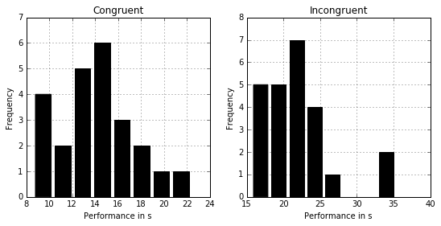

It shows that most of data distribute around the mean either on congruent or incongruent situation. What's more, the peak tends to appear in the mean of performance on each situation.

#### 5. Now, perform the statistical test and report your results. What is your confidence level and your critical statistic value? Do you reject the null hypothesis or fail to reject it? Come to a conclusion in terms of the experiment task. Did the results match up with your expectations?

Set the confidence level equal 95%. As for two tailed t-test, t-critical value is ±2.07.

Here is the result:

t(23) = -8.02, p < .025, two-tailed

95% CI = (-10.02, -5.91)

d = -1.64, r² = .74

Because t < -2.07, we reject the null hypothesis. That's to say, there is a significant difference between the two conditions.

Therefore, the result does match up my expectation.

### Appendix: Project code

```python
from numpy import *
import pandas as pd
```

```python
# For question 3
data = pd.read_csv('stroopdata.csv')
x = data.ix[:,0]
y = data.ix[:,1]

x_bar = x.mean()
y_bar = y.mean()
median_x = x.median()
median_y = y.median()
s_x = x.std(ddof=1)
s_y = y.std(ddof=1)
```

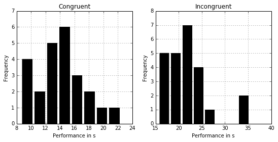

```python
# For question 4
%matplotlib inline
import matplotlib.pyplot as plt

plt.rc("figure", figsize=(9,4))
fig, axes = plt.subplots(nrows=1, ncols=2)
axes[0].hist(x, bins=8, color="k", rwidth= .8)
axes[1].hist(y, bins=8, color="k", rwidth= .8)

axes[0].set(xlabel="Performance in s", ylabel="Frequency", title="Congruent", ylim=[0,7])
axes[1].set(xlabel="Performance in s", ylabel="Frequency", title="Incongruent", ylim=[0,8])
for ax in axes:
    ax.grid(True)

plt.show()
```

```python
# For question 5
n = len(x)
df = n-1
t_critical = 2.069
D = mean(x-y)
s = std(x-y, ddof=1)
SE = s/sqrt(n)
t = (D-0)/SE
CI_ub = D+t_critical*SE
CI_lb = D-t_critical*SE
r = t**2/(t**2+df)
d = (D-0)/s

print("t=%.2f CI=(%.2f,%.2f) d=%.2f r²=%.2f" % (t, CI_lb, CI_ub, d, r))
```

```
t=-8.02 CI=(-10.02,-5.91) d=-1.64 r²=0.74
```